# Engenharia de caracteristicas

## *Dataset* de artigos do NIPS (1987 à 2015)

Esse dataset está disponível no [repositório de *machine learning* da UCI](https://archive.ics.uci.edu/ml/datasets/NIPS+Conference+Papers+1987-2015#).

Os demais dados é a contagem de quantas vezes cada palavra aparece em cada artigo, sendo assim, temos um *Bag Of Words* dos artigos. Porém a disposição da matriz não está condizente com o que estamos acostumados a trabalhar, sendo que as *features* se encontram nas linhas. Para tanto, é necessário criar a transposta dessa matriz, para que se torne mais familiar e possamos utiliza-la em nossos métodos.

Após feito a transposta do *dataset*, ele toma a forma de uma matriz esparsa com a contagem da frequência de cada palavra, como a abaixo.

```python
import numpy as np
import pandas as pd
import matplotlib.pyplot as plt
from time import time
%matplotlib notebook
```

```python
dataset = pd.read_csv('NIPS_1987-2015_transpose.csv')
dataset.head(5)
```

|  | Unnamed: 0 | abalone | abbeel | abbott | abbreviate | abbreviated | abc | abeles | abernethy | abilistic | ... | zhou | zhu | zien | zilberstein | zones | zoo | zoom | zou | zoubin | zurich |
| --- | --- | --- | --- | --- | --- | --- | --- | --- | --- | --- | --- | --- | --- | --- | --- | --- | --- | --- | --- | --- | --- |
| 0 | 1987_1 | 0 | 0 | 0 | 0 | 0 | 0 | 0 | 0 | 0 | ... | 0 | 0 | 0 | 0 | 0 | 0 | 0 | 0 | 0 | 0 |
| 1 | 1987_2 | 0 | 0 | 0 | 0 | 0 | 0 | 0 | 0 | 0 | ... | 0 | 0 | 0 | 0 | 0 | 0 | 0 | 0 | 0 | 0 |
| 2 | 1987_3 | 0 | 0 | 0 | 0 | 0 | 0 | 0 | 0 | 0 | ... | 0 | 0 | 0 | 0 | 0 | 0 | 0 | 0 | 0 | 0 |
| 3 | 1987_4 | 0 | 0 | 0 | 0 | 0 | 0 | 0 | 0 | 0 | ... | 0 | 0 | 0 | 0 | 0 | 0 | 0 | 0 | 0 | 0 |
| 4 | 1987_5 | 0 | 0 | 0 | 0 | 0 | 0 | 0 | 0 | 0 | ... | 0 | 0 | 0 | 0 | 0 | 0 | 0 | 0 | 0 | 0 |

5 rows × 11464 columns

## Histograma de maximos

Agora que temos nossa matriz em formado familiar, podemos estuda-la.

O primeiro passo que pode ser tomado é a visualização do histograma da matriz por completo. Para realizar essa tarefa, foi feita a contagem das frequências máximas de cada *token*, dessa forma podemos agrupar no histograma *tokens* com frequências iguais e visualizar se realmente todas as 11464 palavras são úteis para nós.

Então, nós primeiro:

- fazemos a contagem dos máximos de cada *token*;
- Retiramos a coluna de ano_id dessa contagem;
- Criamos um gráfico com ajuda da biblioteca `matplotlib` com 40 "baldes".

```python
max_feature_counts = dataset.max()
max_feature_counts = max_feature_counts[1:] # Retirando a coluna Xyear_ID
```

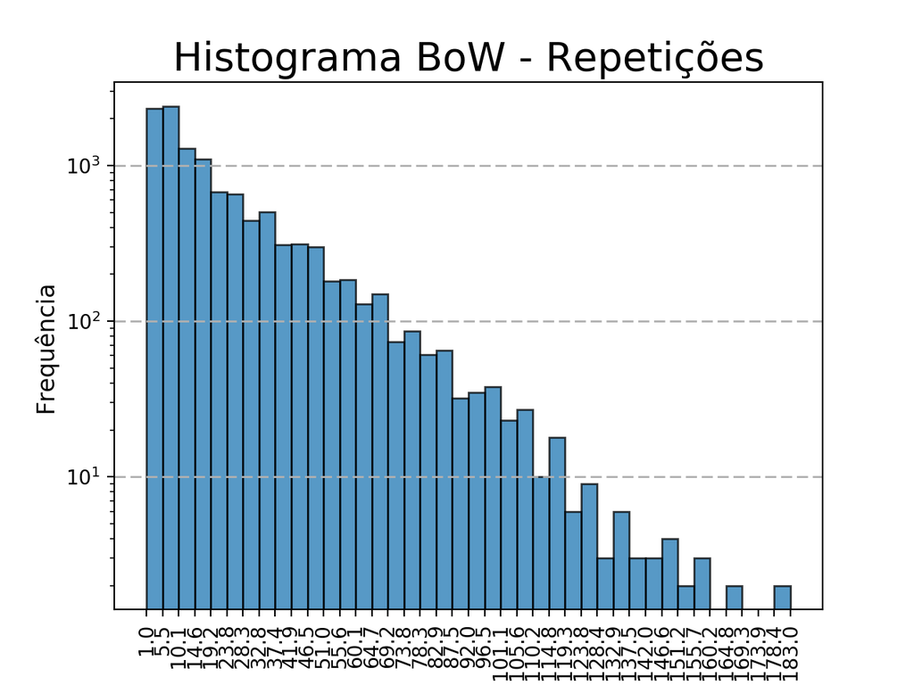

```
[  2.32400000e+03   2.40300000e+03   1.28500000e+03   1.09700000e+03
   6.73000000e+02   6.58000000e+02   4.45000000e+02   5.01000000e+02
   3.09000000e+02   3.13000000e+02   3.00000000e+02   1.81000000e+02
   1.84000000e+02   1.29000000e+02   1.49000000e+02   7.40000000e+01
   8.60000000e+01   6.10000000e+01   6.50000000e+01   3.20000000e+01
   3.50000000e+01   3.80000000e+01   2.30000000e+01   2.70000000e+01
   1.00000000e+01   1.80000000e+01   6.00000000e+00   9.00000000e+00
   3.00000000e+00   6.00000000e+00   3.00000000e+00   3.00000000e+00
   4.00000000e+00   2.00000000e+00   3.00000000e+00   0.00000000e+00
   2.00000000e+00   0.00000000e+00   0.00000000e+00   2.00000000e+00] [   1.      5.55   10.1    14.65   19.2    23.75   28.3    32.85   37.4
   41.95   46.5    51.05   55.6    60.15   64.7    69.25   73.8    78.35
   82.9    87.45   92.     96.55  101.1   105.65  110.2   114.75  119.3
  123.85  128.4   132.95  137.5   142.05  146.6   151.15  155.7   160.25
  164.8   169.35  173.9   178.45  183.  ]
```

```python
n, bins, patches = plt.hist(max_feature_counts, 40, log=True, ec='black', alpha=0.75, align='mid')
plt.title('Histograma BoW - Repetições', fontsize=20)
plt.xlabel('Maximo encontrado', fontsize=12)
plt.xticks(bins, rotation=90)
plt.ylabel('Frequência', fontsize=12)
ax = plt.gca()
ax.grid(axis='y', linestyle='--', linewidth=1)
plt.show()
print(n, bins)
```

Podemos visualizar no histograma que cerca de **7782 *tokens*** tem uma frequência máxima de até 24 vezes e outros 4 *tokens* tem a frequência máxima acima de 164 vezes. Então podemos afirmar, apenas com base nesse histograma, que 7782 *tokens* podem ser retirados, já que o máximo de vezes que aparecem em um único artigo não é relevante.

A mesma afirmação não é verdadeira para o restante do vocabulário, já que uma alta frequência máxima não nos diz se esse *token* está presente em apenas poucos artigos ou não. O que nos leva para nossa próxima análise.

## Estudo dos termos frequentes

Próximo passo é então estudar quais são os termos mais frequentes no nosso vocabulário, para então ter uma ideia de qual é a nossa amostra.

Para isso é feita a ordenação das frequências máximas já coletadas e estudado cada *token* individualmente na ordem das suas frequências máximas.

```python
sorted_values = max_feature_counts.sort_values(ascending=False)
sorted_columns = sorted_values.axes[0]
```

```python
print('{} - {}\t{} - {} - {}\t{} - {}'.format('token',
                                             'freq.',
                                             'mediana',
                                             'media',
                                             'Som. freq.',
                                             'qnt. !=0',
                                             'qnt. ==0'))
for index, s in enumerate(sorted_columns):
    if index > 69:
        break
    count_raw = np.array(dataset.loc[:, s])
    non_zeros = np.sort([t for t in count_raw if t != 0])
    zeros = [t for t in count_raw if t == 0]

    print('%s - %0.f\t%0.f - %0.f - %0.f\t%0.f - %0.f' % (s,
                                                 sorted_values[index],
                                                 np.median(non_zeros),
                                                 np.mean(non_zeros),
                                                 np.sum(non_zeros),
                                                 len(non_zeros),
                                                 len(zeros)))
```

```
token - freq.	mediana - media - Som. freq.	qnt. !=0 - qnt. ==0
reward - 183	7 - 12 - 6530	523 - 5288
choice - 180	1 - 2 - 6179	2617 - 3194
gaze - 168	3 - 11 - 612	58 - 5753
clustering - 167	2 - 9 - 10354	1197 - 4614
shape - 160	1 - 4 - 4009	1113 - 4698
noise - 159	3 - 7 - 17104	2564 - 3247
risk - 156	2 - 7 - 5659	826 - 4985
tensor - 155	2 - 11 - 2803	252 - 5559
matrix - 153	5 - 10 - 31721	3283 - 2528
tree - 151	3 - 10 - 10908	1140 - 4671
data - 150	10 - 14 - 72295	5022 - 789
norm - 149	2 - 6 - 8893	1548 - 4263
policy - 148	11 - 19 - 10811	563 - 5248
model - 144	10 - 16 - 80080	4909 - 902
kernel - 144	4 - 11 - 18411	1626 - 4185
survival - 143	1 - 4 - 349	79 - 5732
map - 142	2 - 5 - 8973	1803 - 4008
chain - 141	2 - 4 - 3932	980 - 4831
learning - 141	10 - 15 - 76406	5058 - 753
scene - 137	2 - 5 - 3016	610 - 5201
lambda - 136	2 - 8 - 595	75 - 5736
reference - 134	1 - 3 - 1962	779 - 5032
teaching - 134	1 - 5 - 424	88 - 5723
saliency - 133	4 - 13 - 1347	104 - 5707
top - 133	2 - 3 - 6737	2183 - 3628
causal - 132	2 - 8 - 2170	271 - 5540
domains - 132	1 - 3 - 2488	907 - 4904
loss - 131	2 - 7 - 14564	2012 - 3799
tracking - 128	1 - 5 - 2222	490 - 5321
influence - 128	1 - 2 - 2273	997 - 4814
macro - 125	1 - 6 - 391	62 - 5749
motion - 125	2 - 8 - 5453	721 - 5090
segmentation - 125	2 - 6 - 3906	653 - 5158
feedback - 125	2 - 4 - 3527	792 - 5019
step - 125	3 - 4 - 16314	3642 - 2169
stop - 124	1 - 2 - 949	467 - 5344
graph - 124	3 - 9 - 14980	1676 - 4135
rank - 123	3 - 8 - 8351	1093 - 4718
change - 121	1 - 3 - 6152	2275 - 3536
```

[output cut: 16 more lines]

```
search - 116	2 - 5 - 9316	2030 - 3781
annotator - 116	1 - 11 - 220	20 - 5791
jigsaw - 116	1 - 20 - 122	6 - 5805
layer - 116	4 - 8 - 11645	1440 - 4371
examples - 115	2 - 4 - 13043	2963 - 2848
pdmm - 115	115 - 115 - 115	1 - 5810
time - 114	6 - 10 - 46402	4794 - 1017
annotations - 113	1 - 5 - 633	131 - 5680
treewidth - 113	2 - 8 - 461	55 - 5756
region - 113	2 - 4 - 5384	1518 - 4293
embedding - 112	2 - 6 - 2891	508 - 5303
object - 112	2 - 8 - 10713	1337 - 4474
network - 111	5 - 11 - 33429	3044 - 2767
networks - 111	3 - 7 - 22496	3243 - 2568
lattice - 111	2 - 4 - 784	177 - 5634
```

Para visualizar melhor o dataset utilizamos de valores como:

- Frequência máxima encontrada para o *token*;
- Mediana e média;
- Soma das frequências;
- Quantidade de artigos que possuem o *token* e não possuem.

Podemos notar que algumas peculiaridades com esses valores:

- Existem palavras que possuem alta frequência na maioria dos artigos, apenas comparando a mediana e a média, onde ambas tem um alto valor;
- Existem palavras similares;
- Existem *tokens* que aparecem em poucos artigos;
  - Com alta frequência (*ssda* 3 artigos, 110 máx);
  - Com baixa frequência (*cooperate* 34, 5 máx);
- Existem *tokens* que aparecem em muitos artigos (data 5022 artigos);

Com base nisso podemos retirar os *tokens* que se encaixam em tais peculiaridades, para tentar reduzir a dimensionalidade do nosso problema.

# Verificando vocabulário

Logo após o estudo do *dataset* pela frequência dos *tokens*, podemos estudar como nosso vocabulário está construido. Faremos isso com o intuito de ver para quais *tokens* existem outros similares no mesmo vocabulário.

Essa analise é pertinente, já que podemos reduzir vários *tokens* a apenas um somando as suas frequências, e dessa forma reduzindo drasticamente nossa dimensionalidade.

Para gerar essa análise utilizaremos a biblioteca `NLTK` e seu `PorterStemmer` para verificar quais *tokens* tem a mesma raiz gramatical e agrupa-los.

```python
import nltk
from nltk.stem.porter import PorterStemmer

columns = dataset.columns[1:]
stemmer = PorterStemmer()
steammed_columns = [stemmer.stem(word) for word in columns]
```

```python
repeated_tokens = []
for token in sorted(set(steammed_columns)):
    indexes = [i for i, x in enumerate(steammed_columns) if x == token]
    if len(indexes) > 1:
        repeated_tokens.append((token, indexes))
```

```python
repeated_tokens[:10]
```

```
[('abbrevi', [3, 4]),
 ('abil', [9, 10]),
 ('absolut', [19, 20]),
 ('absorb', [21, 22]),
 ('abstract', [24, 25, 26, 27]),
 ('abund', [28, 29]),
 ('acceler', [33, 34, 35, 36, 37]),
 ('accept', [38, 39, 40, 41, 42, 43]),
 ('access', [44, 45, 46, 47]),
 ('accompani', [49, 50])]
```

Com essa análise podemos verificar que existem diversos *tokens* repetidos em nossa base, onde um *token* , pode chegar a ter **mais de 20** outros similares. **('gener' 21)**

```python
import nltk
from nltk.stem.porter import PorterStemmer

def extract_repeated_tokens(tokens):
    stemmer = PorterStemmer()
    steammed_columns = [stemmer.stem(word) for word in tokens]

    repeated_tokens = []
    for token in sorted(set(steammed_columns)):
        indexes = [i for i, x in enumerate(steammed_columns) if x == token]
        if len(indexes) > 1:
            repeated_tokens.append((token, indexes))

    return repeated_tokens
```

## Remodelar *dataset*

Agora que as analises foram feitas, já sabemos os passos que podemos seguir para reduzir a dimensionalidade do nosso problema.

Agora para conseguirmos retirar o máximo de *tokens* sem perder informações valiosas do nosso *dataset* temos que seguir uma ordem fixa para reduçao de tal dimensionalidade.

- O primeiro passo é remover as colunas que possuem *tokens* similares a outros, dessa forma podemos agrupar vários *tokens* em uma só coluna, sem perda de informação.
- O segundo passo é remover os *tokens* com baixas frequências máximas.
- O terceiro passo é remover as colunas com base na **proporção** de artigos que elas cobrem.
- Então por último é remover os **artigos nulos**, que não possuem qualquer ocorrência dos *tokens* selecionados.

```python
y = dataset.iloc[:, 0]
```

### Removendo colunas comuns ao *steamming*

Com a redução de features por *steamming* conseguimos reduzir o número de features de 11464 para 7168, representando uma redução de **37%** das features.

```python
def remove_repeated_tokens(data, r_tokens, verbose=0):
    columns_to_drop = []
    j = 0
    for token, indexes in r_tokens:
        for i in range(1, len(indexes)):
            data.iloc[:, indexes[0]] += data.iloc[:, indexes[i]]

            columns = dataset.columns[1:]
            column_to_drop = columns[indexes[i]]
            column_to_add = columns[indexes[0]]

            columns_to_drop.append(column_to_drop)

            if verbose > 1:
                print('Droped\t\'{}\'\tand summed with\t\'{}\'\tToken - {} - {}'
                      .format(column_to_drop, column_to_add, token, indexes))
            elif verbose > 0:
                if j < 15:
                    print('Droped\t\'{}\'\tand summed with\t\'{}\'\tToken - {} - {}'
                      .format(column_to_drop, column_to_add, token, indexes))
        j+=1
    data = data.drop(columns_to_drop, axis=1)
    return data
```

```python
X = dataset.copy()
X = X.drop('Unnamed: 0', axis=1)
t0 = time()
X = remove_repeated_tokens(X, repeated_tokens, verbose = 1)
print('\n\nNew Dimensions: {}'.format(X.shape))
print('Execution time %.3f' % (time() - t0))
```

```
Droped	'abbreviated'	and summed with	'abbreviate'	Token - abbrevi - [3, 4]
Droped	'ability'	and summed with	'abilities'	Token - abil - [9, 10]
Droped	'absolutely'	and summed with	'absolute'	Token - absolut - [19, 20]
Droped	'absorbing'	and summed with	'absorbed'	Token - absorb - [21, 22]
Droped	'abstraction'	and summed with	'abstract'	Token - abstract - [24, 25, 26, 27]
Droped	'abstractions'	and summed with	'abstract'	Token - abstract - [24, 25, 26, 27]
Droped	'abstracts'	and summed with	'abstract'	Token - abstract - [24, 25, 26, 27]
Droped	'abundant'	and summed with	'abundance'	Token - abund - [28, 29]
Droped	'accelerated'	and summed with	'accelerate'	Token - acceler - [33, 34, 35, 36, 37]
Droped	'accelerating'	and summed with	'accelerate'	Token - acceler - [33, 34, 35, 36, 37]
Droped	'acceleration'	and summed with	'accelerate'	Token - acceler - [33, 34, 35, 36, 37]
Droped	'accelerations'	and summed with	'accelerate'	Token - acceler - [33, 34, 35, 36, 37]
Droped	'acceptable'	and summed with	'accept'	Token - accept - [38, 39, 40, 41, 42, 43]
Droped	'acceptance'	and summed with	'accept'	Token - accept - [38, 39, 40, 41, 42, 43]
Droped	'accepted'	and summed with	'accept'	Token - accept - [38, 39, 40, 41, 42, 43]
Droped	'accepting'	and summed with	'accept'	Token - accept - [38, 39, 40, 41, 42, 43]
Droped	'accepts'	and summed with	'accept'	Token - accept - [38, 39, 40, 41, 42, 43]
Droped	'accessed'	and summed with	'access'	Token - access - [44, 45, 46, 47]
Droped	'accesses'	and summed with	'access'	Token - access - [44, 45, 46, 47]
Droped	'accessible'	and summed with	'access'	Token - access - [44, 45, 46, 47]
Droped	'accompaniment'	and summed with	'accompanied'	Token - accompani - [49, 50]
Droped	'accomplished'	and summed with	'accomplish'	Token - accomplish - [51, 52]
Droped	'accordance'	and summed with	'accord'	Token - accord - [53, 54, 55]
Droped	'according'	and summed with	'accord'	Token - accord - [53, 54, 55]
Droped	'accounted'	and summed with	'account'	Token - account - [57, 58, 59, 60]
Droped	'accounting'	and summed with	'account'	Token - account - [57, 58, 59, 60]
Droped	'accounts'	and summed with	'account'	Token - account - [57, 58, 59, 60]
Droped	'accumulated'	and summed with	'accumulate'	Token - accumul - [61, 62, 63, 64, 65, 66]
Droped	'accumulates'	and summed with	'accumulate'	Token - accumul - [61, 62, 63, 64, 65, 66]
Droped	'accumulating'	and summed with	'accumulate'	Token - accumul - [61, 62, 63, 64, 65, 66]
Droped	'accumulation'	and summed with	'accumulate'	Token - accumul - [61, 62, 63, 64, 65, 66]
Droped	'accumulator'	and summed with	'accumulate'	Token - accumul - [61, 62, 63, 64, 65, 66]
Droped	'accurately'	and summed with	'accurate'	Token - accur - [69, 70]


New Dimensions: (5811, 7168)
Execution time 3.374
```

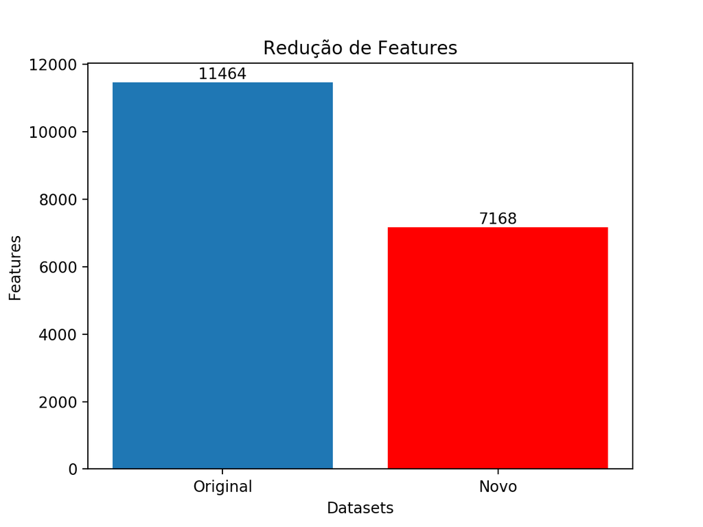

```python
def make_comparative_feature_graph(dataset, X):
    features_count = [dataset.shape[1], X.shape[1]]

    fig, ax = plt.subplots()
    cplt, novo = plt.bar(np.arange(1, 3), features_count)
    novo.set_facecolor('r')
    plt.ylabel('Features')
    plt.xlabel('Datasets')
    plt.title('Redução de Features')
    ax.set_xticks(np.arange(1, 3))
    ax.set_xticklabels(['Original', 'Novo'])

    rects = ax.patches
    for rect, label in zip(rects, features_count):
        height = rect.get_height()
        ax.text(rect.get_x() + rect.get_width()/2, height + 5, label, ha='center', va='bottom')

    plt.show()

make_comparative_feature_graph(dataset, X)
```

### Observando colunas com alta/baixa frequência

Agora podemos observar o nosso novo conjunto de dados e como a máxima frequência dos *tokens* se comportam nele.

Faremos novamente um histograma para as frequências máximas. Com o novo histograma podemos perceber que o número de *tokens* com a frequência máxima abaixo de 24 vezes, caiu para aproximadamente **4297 *tokens***.

```python
def count_max_ocurrences(dataset):
    max_feature_counts = dataset.max()

    sorted_values = max_feature_counts.sort_values(ascending=False)
    sorted_columns = sorted_values.axes[0]

    return (max_feature_counts, sorted_values, sorted_columns)
```

```python
max_feature_counts, sorted_values, sorted_columns = count_max_ocurrences(X)
```

```python
def make_histogram(arr, title, n_partitions=40, verbose=0):
    n, bins, patches = plt.hist(arr, n_partitions, log=True, ec='black', alpha=0.75, align='mid')
    plt.title(title, fontsize=20)
    plt.xlabel('Maximo encontrado', fontsize=12)
    plt.xticks(bins, rotation=90)
    plt.ylabel('Frequência', fontsize=12)
    ax = plt.gca()
    ax.grid(axis='y', linestyle='--', linewidth=1)
    plt.show()

    if verbose > 0:
        print(n, bins)
```

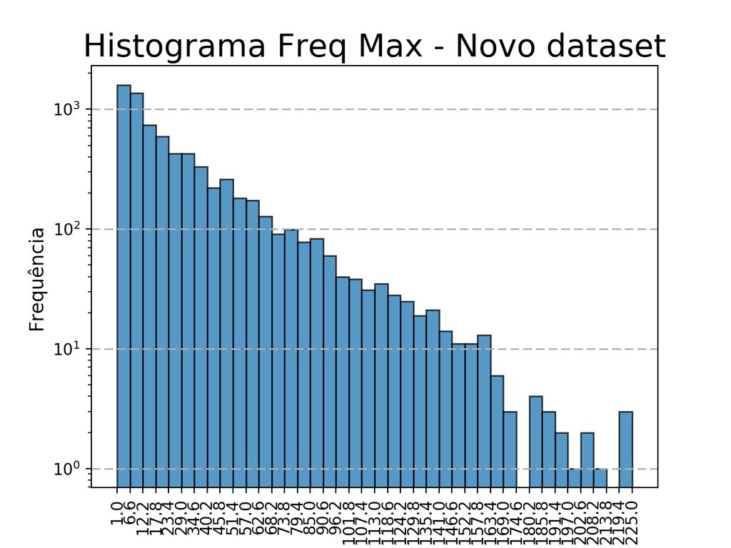

```
[  1.59600000e+03   1.37200000e+03   7.35000000e+02   5.94000000e+02
   4.27000000e+02   4.28000000e+02   3.30000000e+02   2.21000000e+02
   2.59000000e+02   1.82000000e+02   1.74000000e+02   1.28000000e+02
   9.10000000e+01   9.90000000e+01   7.80000000e+01   8.30000000e+01
   6.00000000e+01   4.00000000e+01   3.80000000e+01   3.10000000e+01
   3.50000000e+01   2.80000000e+01   2.50000000e+01   1.90000000e+01
   2.10000000e+01   1.40000000e+01   1.10000000e+01   1.10000000e+01
   1.30000000e+01   6.00000000e+00   3.00000000e+00   0.00000000e+00
   4.00000000e+00   3.00000000e+00   2.00000000e+00   1.00000000e+00
   2.00000000e+00   1.00000000e+00   0.00000000e+00   3.00000000e+00] [   1.     6.6   12.2   17.8   23.4   29.    34.6   40.2   45.8   51.4
   57.    62.6   68.2   73.8   79.4   85.    90.6   96.2  101.8  107.4
  113.   118.6  124.2  129.8  135.4  141.   146.6  152.2  157.8  163.4
  169.   174.6  180.2  185.8  191.4  197.   202.6  208.2  213.8  219.4
  225. ]
```

```python
make_histogram(sorted_values, 'Histograma Freq Max - Novo dataset', verbose = 1)
```

### Removendo colunas baseado na proporção

Por último podemos reduzir ainda mais nosso *dataset* com base na proporção dos *tokens* nos artigos. Onde *tokens* que aparecem em poucos artigos ou *tokens* que aparecem em quase todos os artigos, não são úteis para discriminar nossas amostras das demais.

Para tanto, utilizamos a faixa de *features* **entre 10% e 80%** de proporção.

```python
def remove_low_high_proportion(dataset):
    tokens = dataset.columns
    remove_tokens = []

    for token in tokens:
        token_proportion = len(dataset[dataset[token]>0]) / len(dataset)
        if token_proportion < 0.1 or token_proportion > 0.8:
            remove_tokens.append(token)

    dataset = dataset.drop(remove_tokens, axis=1)

    return (dataset, remove_tokens)
```

```python
X, tokens_removed = remove_low_high_proportion(X)
tokens_removed[:10]
```

```
['abalone',
 'abbeel',
 'abbott',
 'abbreviate',
 'abc',
 'abeles',
 'abernethy',
 'abilistic',
 'ables',
 'abnormal']
```

Aplicando a remoção por proporção podemos retirar **51%** do dataset original, ficando ao final com apenas **10%** do conjunto de dados inicial.

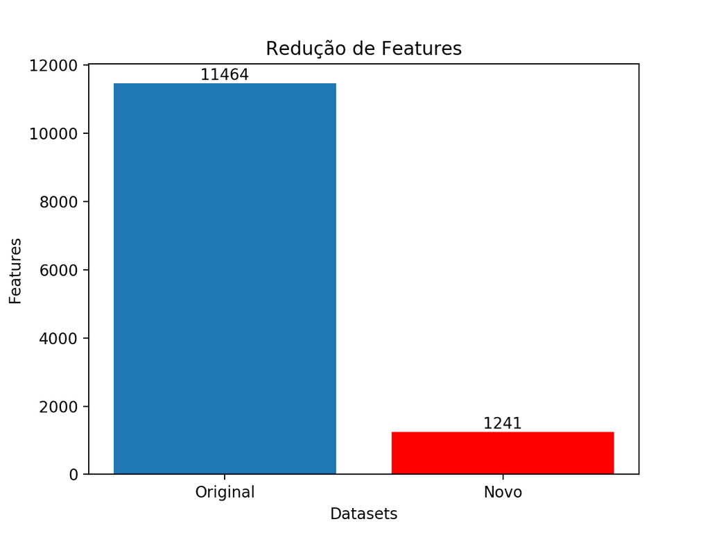

```python
make_comparative_feature_graph(dataset, X)
```

### Removendo colunas baseado na frequência

Com isso podemos agora remover os *tokens* com baixa contagem em sua frequência.

Para realizar a redução, tomamos por base a contagem feita no histograma, onde verificamos que existem vários mais de 4 mil *tokens* com frequencia abaixo de 24 vezes. Porém, não podemos ter certeza de que *tokens* com frequências próximas a 24 vezes não sejam úteis para classificar algum artigo, então utilizamos de algumas regras baseado na frequência máxima para reduzir nosso problema.

E um *token* será enviado para análise de remoção caso a frequência máxima dele for entre 18 e 24 vezes.

```python
def remove_low_counting_tokens(dataset, sorted_columns, sorted_values, bounds=[65,4,18,24]):
    drop_columns = []
    not_sure_to_drop = []
    report = []

    for index, s in enumerate(sorted_columns):
        count_raw = np.array(dataset.loc[:, s])
        non_zeros = [t for t in count_raw if t != 0]
        median = np.median(count_raw)
        mean = np.mean(count_raw)

        # Check if the feature has a high frequency among at least 80% of the samples
        if sorted_values[index] < bounds[0] and len(non_zeros) >= (0.8 * dataset.shape[0]):
            drop_colum = (s, sorted_values[index], median, len(non_zeros))
            report.append(drop_colum)
            drop_columns.append(s)
        # Check if the column is constant throughout at least 60% of the samples
        elif abs(median - mean) <= bounds[1] and len(non_zeros) >= (0.6 * dataset.shape[0]):
            drop_colum = (s, sorted_values[index], median, len(non_zeros))
            report.append(drop_colum)
            drop_columns.append(s)
        # Drop if the max frequency is less than 18
        elif sorted_values[index] < bounds[2]:
            drop_colum = (s, sorted_values[index], median, len(non_zeros))
            report.append(drop_colum)
            drop_columns.append(s)
        # Sent to check if the max frequency is higher than 18 and less than 24
        elif sorted_values[index] < bounds[3]:
            drop_colum = (s, sorted_values[index], median, len(non_zeros))
            not_sure_to_drop.append(s)
        else:
            continue

    dataset = dataset.drop(drop_columns, axis=1)

    return (dataset, not_sure_to_drop, report, drop_columns)
```

```python
max_feature_counts, sorted_values, sorted_columns = count_max_ocurrences(X)
X, columns_to_check, report, columns_droped = remove_low_counting_tokens(X, sorted_columns, sorted_values)
print(len(columns_droped), len(columns_to_check))
print(X.shape)
X.head()
```

```
389 93
(5811, 852)
```

|  | absolute | accept | access | accord | account | accuracies | accurate | across | act | action | ... | wide | width | window | wise | within | word | world | worst | write | year |
| --- | --- | --- | --- | --- | --- | --- | --- | --- | --- | --- | --- | --- | --- | --- | --- | --- | --- | --- | --- | --- | --- |
| 0 | 0 | 0 | 1 | 1 | 0 | 0 | 0 | 0 | 0 | 0 | ... | 0 | 0 | 0 | 0 | 0 | 1 | 0 | 0 | 1 | 0 |
| 1 | 1 | 0 | 0 | 0 | 0 | 0 | 0 | 3 | 0 | 0 | ... | 1 | 0 | 0 | 0 | 0 | 0 | 0 | 0 | 0 | 1 |
| 2 | 0 | 1 | 0 | 0 | 0 | 0 | 0 | 0 | 0 | 0 | ... | 1 | 0 | 0 | 0 | 1 | 0 | 0 | 0 | 3 | 1 |
| 3 | 0 | 0 | 0 | 0 | 0 | 0 | 0 | 0 | 0 | 0 | ... | 0 | 0 | 0 | 0 | 2 | 0 | 1 | 0 | 0 | 0 |
| 4 | 1 | 0 | 0 | 0 | 0 | 0 | 0 | 0 | 0 | 0 | ... | 3 | 2 | 0 | 2 | 2 | 0 | 0 | 1 | 0 | 0 |

5 rows × 852 columns

Com isso conseguimos reduzir ainda mais nosso dataset, chegando a um percentual de **7%** do *dataset* inicial.

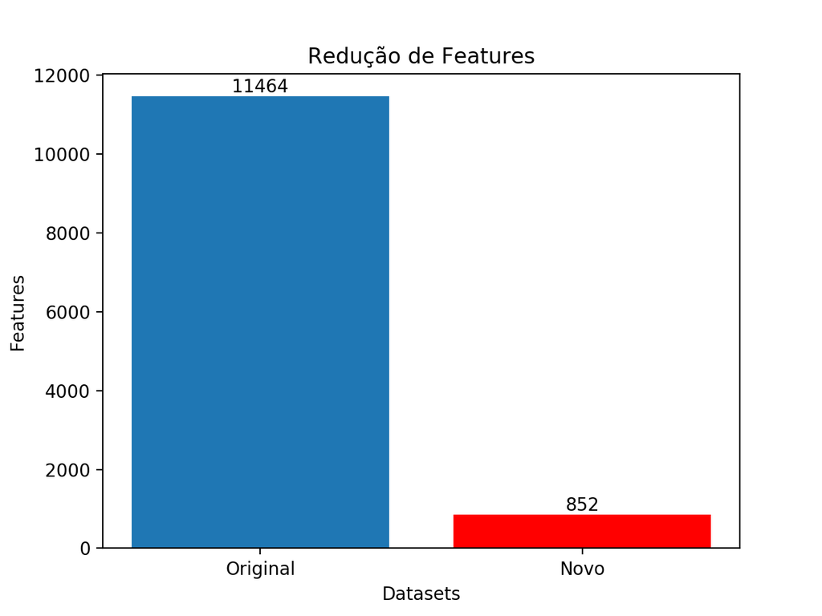

```python
make_comparative_feature_graph(dataset, X)
```

### Removendo linhas nulas

Agora devemos remover todo artigo nulo, que não houver contagem das *features* selecionadas.

```python
def remove_nul_rows(dataset):
    remove_rows = []

    for i in range(len(dataset)):
        total_words = sum(dataset.iloc[i, :])
        if total_words == 0:
            remove_rows.append(i)

    indexes_to_drop = dataset.index[remove_rows]
    dataset = dataset.drop(indexes_to_drop, axis=0)

    return (dataset, indexes_to_drop)
```

```python
X, indexes_removed = remove_nul_rows(X)
print('Removidos {} artigos: {}'.format(len(indexes_removed), list(indexes_removed)))
```

```
Removidos 7 artigos: [2452, 3277, 4062, 4099, 4204, 4228, 5595]
```

## Remodelando em um passo

Agora podemos executar todos os passos de uma só vez para facilitar.

```python
dataset = pd.read_csv('NIPS_1987-2015_transpose.csv')
y = dataset.iloc[:, 0]
X = dataset.copy()
X = X.drop('Unnamed: 0', axis=1)

t0 = time()

repeated_tokens = extract_repeated_tokens(X.columns)
X = remove_repeated_tokens(X, repeated_tokens)
max_feature_counts, sorted_values, sorted_columns = count_max_ocurrences(X)
X, columns_to_check, report, columns_droped = remove_low_counting_tokens(X, sorted_columns, sorted_values)
X, outliers = remove_low_high_proportion(X)
X, nul_rows = remove_nul_rows(X)
y = y.drop(nul_rows, axis=0)

print('New Dimensions: {}'.format(X.shape))
print('Execution time %.3fs' % (time() - t0))
```

```
New Dimensions: (5804, 852)
Execution time 67.027s
```

Por fim temos este histograma para as *features* selecionadas.

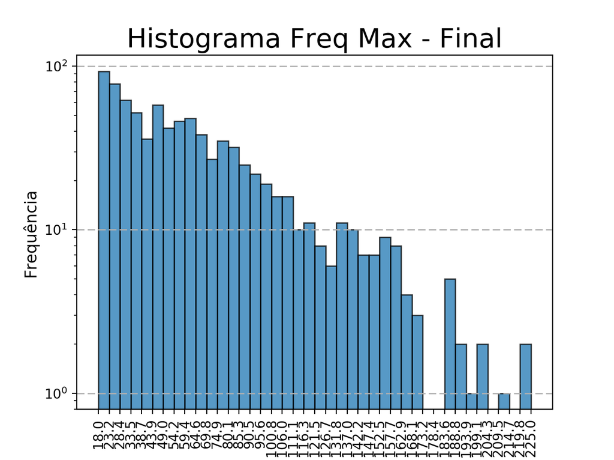

```python
max_feature_counts, sorted_values, sorted_columns = count_max_ocurrences(X)
make_histogram(sorted_values, 'Histograma Freq Max - Final')
```

## Salvando novo dataset remodelado

Ao final apenas nos resta salvar o novo conjunto de dados para que possamos então usa-lo futuramente.

```python
new_X = X.assign(y=pd.Series(y).values)
new_X.to_csv('NIPS_1987-2015_remodeled_755.csv', index=False)
```

Uma variação para teste seria salvar apenas as 300 primeiras palavras com as maiores ocorrências no conjunto por inteiro.

```python
lcolumns = X.sum(0).nlargest(300).index.tolist()
X1 = X[lcolumns]
X1 = X1.assign(y=pd.Series(y).values)
X1.to_csv('NIPS_1987-2015_remodeled_300.csv', index=False)
```

@DaniloBarros